# *t*-Test Assumptions

**STA4173: Biostatistics**  
Spring 2025

## Introduction: Assumptions

- We have now learned one- and two-sample *t*-tests.
- Recall, when we have two samples, they can be independent samples or dependent samples.
  - Independent samples: two-sample *t*-test
  - Dependent samples: paired *t*-test (one-sample *t*-test on difference)
- Today we will discuss how to assess the assumptions on *t*-tests.

## Normality Assumption: Set Up

- All *t*-tests assume approximate normality of the data.
  - In the case of one-sample *t*-tests, the measure of interest must somewhat follow a normal distribution.
  - In the case of two-sample *t*-tests, the measure of interest *in each group* must somewhat follow a normal distribution.
- Note that a paired *t*-test is technically a one-sample *t*-test, so we will examine normality of the difference.

## Normality Assumption: Set Up

- There are formal tests for normality ([see article here](https://www.ncbi.nlm.nih.gov/pmc/articles/PMC3693611/)), however, we will not use them.
  - Tests for normality are not well-endorsed by statisticians.
- Instead, we will assess normality using a quantile-quantile (q-q) plot.
  - This is a scatterplot that will form a 45° line if the assumed distribution is correct.
  - [Here is more information about q-q plots](https://data.library.virginia.edu/understanding-q-q-plots/).
- We will create q-q plots for:
  - The measurements in the case of the one-sample *t*-test.
  - The measurements from each group in the case of the two-sample *t*-test.
  - The difference between the groups in the case of the paired *t*-test.

## Normality Assumption: R Syntax

- We will assess the normality assumption graphically using a q-q plot
- A package was written by a former student, [`classpackage`](https://github.com/ieb2/classpackage).
  - If you **are** working on the server, the package is already installed.
  - If you are **not** working on the server, please ask me for the code needed to install.

## Normality Assumption: Independent Data - R Syntax

- Once installed, we call the package,

```r
library(classpackage)
```

- While there are several functions in this package, we are currently interested in the `independent_qq_plot()` function.

```r
dataset_name %>% independent_qq_plot(variable = "continuous variable",
                                     grouping_variable = "grouping variable")
```

- This will provide the the q-q plot for the two-sample *t*-test (i.e., for independent data).

## Normality Assumption: Independent Data - Example

- Recall the penguin example for the two-sample *t*-test.
  - Is the body mass different for males and females?

```r
penguins <- palmerpenguins::penguins
head(penguins, n=3)
```

| species | island | bill_length_mm | bill_depth_mm | flipper_length_mm | body_mass_g | sex | year |
| --- | --- | --- | --- | --- | --- | --- | --- |
| Adelie | Torgersen | 39.1 | 18.7 | 181 | 3750 | male | 2007 |
| Adelie | Torgersen | 39.5 | 17.4 | 186 | 3800 | female | 2007 |
| Adelie | Torgersen | 40.3 | 18.0 | 195 | 3250 | female | 2007 |

- Requesting the q-q plot,

```r
penguins %>% independent_qq_plot(variable = "body_mass_g",
                                 grouping_variable = "sex")
```

## Normality Assumption: Independent Data - Example

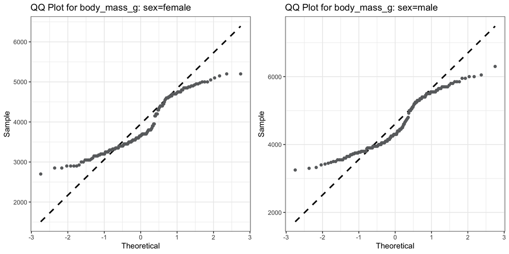

## Normality Assumption: Dependent Data - R Syntax

- While there are several functions in the `classpackage` package, we are now interested in the `dependent_qq_plot()` function.

```r
wide_data %>% dependent_qq_plot(variable = "Display Name of Continuous Variable",
                                grouping_variable = " ", # do not edit this line
                                first_group = "first_variable", # first column for comparison
                                second_group = "second_variable") # second column for comparison
```

- This will provide the the q-q plot for the paired *t*-test (i.e., for dependent data).

## Normality Assumption: Repair Estimates

- Recall the repair estimate example for the dependent *t*-test.

```r
garage <- tibble(g1 = c(17.6, 20.2, 19.5, 11.3, 13.0,
                        16.3, 15.3, 16.2, 12.2, 14.8,
                        21.3, 22.1, 16.9, 17.6, 18.4),
                 g2 = c(17.3, 19.1, 18.4, 11.5, 12.7,
                        15.8, 14.9, 15.3, 12.0, 14.2,
                        21.0, 21.0, 16.1, 16.7, 17.5))
```

- Requesting the q-q plot,

```r
garage %>% dependent_qq_plot(variable = "estimate",
                             grouping_variable = "garage",
                             first_group = "g1",
                             second_group = "g2")
```

## Normality Assumption: Repair Estimates

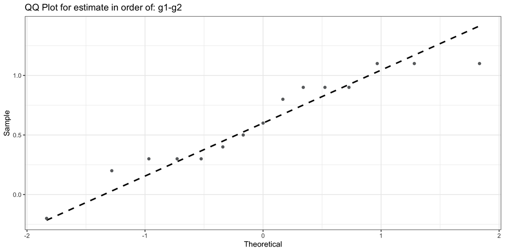

## Wrap Up

- **Important note!!**
  - *I do not expect you to agree with my assessment of q-q plots!*
  - What I do expect is that you know what to do after making your assessment.
- Next up:
  - What happens if we do not meet the assumption for a *t*-test….?